# Cayla Stevenson DS 220 Project #2 on Data Analysis with Python - 12/7/23

- ** The broad goal for your Project #2 is to demonstrate some understanding and appreciation for data analysis using some Python and its growing suite of Data Science libraries with a special focus on the Pandas library. The Pandas library builds on the NumPy and MatPlotlib libraries. In particular you are required to:

• Identify a raw public dataset of interest to you and download the raw data to your computer.

• Frame some 6 to 10 Questions that you or others in the area may want to answer analyzing this data.

• Load your data set into a Pandas data frame and do some preprocessing and cleaning if needed (this should be documented)

• Perform exploratory data analysis & visualization

• Map your questions as queries on the Pandas dataframe to generate answers

• Derive insight(s) using answers to your questions

• Communicates those insights as actionable text or a story that may be easy to communicate and share with others interested in the same dataset. • Publish your work on github pages at a reachable UR

# Part 1- Selection

- I chose to do my projct using the Titanic dataset that was listed on the project instructions. I believe it is data that people would be interested in and would want to look at to break down and find certain individuals, look at numbers, and specifics. My goal with this project is to be able to look at real data to understand and analyze it like I would be presenting it to people that do not know anything about coding and extracting data.

# Part 2- Importing Titanic dataset

- Here, I am loading the data from the sinking of the Titanic ship of 1912 into my codespace using Pandas and Matplotlib, resources that assist in observing python libraries and datasets.

```python
import pandas as pd
import matplotlib.pyplot as plt
data = pd.read_csv("titanic.csv")
```

- Since I ran the code cell and got a green check mark, I am now ready to clean the table of Titanic data. First, we need to see a list of all the columns on the table:

```python
data.columns
```

```
Index(['PassengerId', 'Survived', 'Pclass', 'Name', 'Sex', 'Age', 'SibSp',
       'Parch', 'Ticket', 'Fare', 'Cabin', 'Embarked'],
      dtype='object')
```

- Each of these columns represent something important about the Titanic and the individuals on the ship. **Passengerid** is a number used to identify every person in the ship.

**Survived** column has 0's and 1's. 0 = did not survive, 1 = did survive.

**Pclass** is the level of importance for each passenger. 1 being most important, and 3 being least (possibly servants, chefs, etc.) **1 = first class, 2 = second class, 3 = third class**

**Name** is the name of the passengers

**Sex** is the gender of the passenger

**Age** is the number of years the passenger had lived at the time of the Titanic sinking

**SibSp** is the number of siblings or spouses the passenger had on board

**Parch** is the number of parents or children the passenger had on board

**Ticket** is the ticket number of the passenger

**Fare** is how much the passenger paid to be on the ship

**Cabin** is where the passenger stayed on the ship

**Embarked** is which port the passenger board the ship on. (S = Southhampton, C = Cherbourg, Q = Queenstown)

All of these columns will be useful when making our queries for this dataset, so we will not delete any of them.

- Now, we need to display the first 5 rows of the full table:

```python
data.head(5)
```

|  | PassengerId | Survived | Pclass | Name | Sex | Age | SibSp | Parch | Ticket | Fare | Cabin | Embarked |
| --- | --- | --- | --- | --- | --- | --- | --- | --- | --- | --- | --- | --- |
| 0 | 1 | 0 | 3 | Braund, Mr. Owen Harris | male | 22.0 | 1 | 0 | A/5 21171 | 7.2500 | NaN | S |
| 1 | 2 | 1 | 1 | Cumings, Mrs. John Bradley (Florence Briggs Th... | female | 38.0 | 1 | 0 | PC 17599 | 71.2833 | C85 | C |
| 2 | 3 | 1 | 3 | Heikkinen, Miss. Laina | female | 26.0 | 0 | 0 | STON/O2. 3101282 | 7.9250 | NaN | S |
| 3 | 4 | 1 | 1 | Futrelle, Mrs. Jacques Heath (Lily May Peel) | female | 35.0 | 1 | 0 | 113803 | 53.1000 | C123 | S |
| 4 | 5 | 0 | 3 | Allen, Mr. William Henry | male | 35.0 | 0 | 0 | 373450 | 8.0500 | NaN | S |

- Then, we need to display the last 5 rows of the full table:

```python
data.tail(5)
```

|  | PassengerId | Survived | Pclass | Name | Sex | Age | SibSp | Parch | Ticket | Fare | Cabin | Embarked |
| --- | --- | --- | --- | --- | --- | --- | --- | --- | --- | --- | --- | --- |
| 886 | 887 | 0 | 2 | Montvila, Rev. Juozas | male | 27.0 | 0 | 0 | 211536 | 13.00 | NaN | S |
| 887 | 888 | 1 | 1 | Graham, Miss. Margaret Edith | female | 19.0 | 0 | 0 | 112053 | 30.00 | B42 | S |
| 888 | 889 | 0 | 3 | Johnston, Miss. Catherine Helen "Carrie" | female | NaN | 1 | 2 | W./C. 6607 | 23.45 | NaN | S |
| 889 | 890 | 1 | 1 | Behr, Mr. Karl Howell | male | 26.0 | 0 | 0 | 111369 | 30.00 | C148 | C |
| 890 | 891 | 0 | 3 | Dooley, Mr. Patrick | male | 32.0 | 0 | 0 | 370376 | 7.75 | NaN | Q |

- Now, we need to look at how many rows and columns are in the table using the .shape() function. **There are 891 rows and 12 columns**

```python
data.shape
```

```
(891, 12)
```

- Now, lets sort the table by name

```python
data.sort_values('Name')
```

|  | PassengerId | Survived | Pclass | Name | Sex | Age | SibSp | Parch | Ticket | Fare | Cabin | Embarked |
| --- | --- | --- | --- | --- | --- | --- | --- | --- | --- | --- | --- | --- |
| 845 | 846 | 0 | 3 | Abbing, Mr. Anthony | male | 42.0 | 0 | 0 | C.A. 5547 | 7.5500 | NaN | S |
| 746 | 747 | 0 | 3 | Abbott, Mr. Rossmore Edward | male | 16.0 | 1 | 1 | C.A. 2673 | 20.2500 | NaN | S |
| 279 | 280 | 1 | 3 | Abbott, Mrs. Stanton (Rosa Hunt) | female | 35.0 | 1 | 1 | C.A. 2673 | 20.2500 | NaN | S |
| 308 | 309 | 0 | 2 | Abelson, Mr. Samuel | male | 30.0 | 1 | 0 | P/PP 3381 | 24.0000 | NaN | C |
| 874 | 875 | 1 | 2 | Abelson, Mrs. Samuel (Hannah Wizosky) | female | 28.0 | 1 | 0 | P/PP 3381 | 24.0000 | NaN | C |
| ... | ... | ... | ... | ... | ... | ... | ... | ... | ... | ... | ... | ... |
| 286 | 287 | 1 | 3 | de Mulder, Mr. Theodore | male | 30.0 | 0 | 0 | 345774 | 9.5000 | NaN | S |
| 282 | 283 | 0 | 3 | de Pelsmaeker, Mr. Alfons | male | 16.0 | 0 | 0 | 345778 | 9.5000 | NaN | S |
| 361 | 362 | 0 | 2 | del Carlo, Mr. Sebastiano | male | 29.0 | 1 | 0 | SC/PARIS 2167 | 27.7208 | NaN | C |
| 153 | 154 | 0 | 3 | van Billiard, Mr. Austin Blyler | male | 40.5 | 0 | 2 | A/5. 851 | 14.5000 | NaN | S |
| 868 | 869 | 0 | 3 | van Melkebeke, Mr. Philemon | male | NaN | 0 | 0 | 345777 | 9.5000 | NaN | S |

891 rows × 12 columns

# Part 3- Queries

Now that we have cleaned and sorted the data, we are ready to write queries/ questions that people may ask when looking at the data. We will come up with 6 questions to show that we can code queries to see results from a dataset:

1.) Select all rows in the dataset for the people that are **male** and display them in a table.

2.) Select all rows in the dataset for people that embarked at the **Southhampton port**.

3.) Display a table that shows all passenger that had more than **3** Siblings or Spouses on the Titanic.

4.) Display a graph with 4 bars. 2 for males **(1 for survivors, one for those that died)** and 2 for females **(1 for survivors, one for those that died)**.

5.) Create **3** graphs that separates all passengers by PClass (level of impportance; 1 being most important, 3 being least). Each graph should have the information of which port they embarked on and if they survived.

6.) Display a histogram graph that shows all the passengers on the Titanic ship **age and how many passengers had the same age.**

**1.) Select all rows in the dataset for people that are male and display them in a table**

```python
data[data['Sex'] == 'male']
```

|  | PassengerId | Survived | Pclass | Name | Sex | Age | SibSp | Parch | Ticket | Fare | Cabin | Embarked |
| --- | --- | --- | --- | --- | --- | --- | --- | --- | --- | --- | --- | --- |
| 0 | 1 | 0 | 3 | Braund, Mr. Owen Harris | male | 22.0 | 1 | 0 | A/5 21171 | 7.2500 | NaN | S |
| 4 | 5 | 0 | 3 | Allen, Mr. William Henry | male | 35.0 | 0 | 0 | 373450 | 8.0500 | NaN | S |
| 5 | 6 | 0 | 3 | Moran, Mr. James | male | NaN | 0 | 0 | 330877 | 8.4583 | NaN | Q |
| 6 | 7 | 0 | 1 | McCarthy, Mr. Timothy J | male | 54.0 | 0 | 0 | 17463 | 51.8625 | E46 | S |
| 7 | 8 | 0 | 3 | Palsson, Master. Gosta Leonard | male | 2.0 | 3 | 1 | 349909 | 21.0750 | NaN | S |
| ... | ... | ... | ... | ... | ... | ... | ... | ... | ... | ... | ... | ... |
| 883 | 884 | 0 | 2 | Banfield, Mr. Frederick James | male | 28.0 | 0 | 0 | C.A./SOTON 34068 | 10.5000 | NaN | S |
| 884 | 885 | 0 | 3 | Sutehall, Mr. Henry Jr | male | 25.0 | 0 | 0 | SOTON/OQ 392076 | 7.0500 | NaN | S |
| 886 | 887 | 0 | 2 | Montvila, Rev. Juozas | male | 27.0 | 0 | 0 | 211536 | 13.0000 | NaN | S |
| 889 | 890 | 1 | 1 | Behr, Mr. Karl Howell | male | 26.0 | 0 | 0 | 111369 | 30.0000 | C148 | C |
| 890 | 891 | 0 | 3 | Dooley, Mr. Patrick | male | 32.0 | 0 | 0 | 370376 | 7.7500 | NaN | Q |

577 rows × 12 columns

Looking at the table, you can see that there was a total of 577 men on the ship. They all range from different class, age, and ports they got on at but since there are 891 people on the ship, we can conclude that more than half of the total people on the ship were male.

**2.) Select al rows in the dataset for people that embarked at the Southhampton port.**

We can use the Boolean condition below to select the embarked column with rows that will display all the passengers that embarked at 'S' or the Southhampton port.

```python
data[data['Embarked'] == 'S']
```

|  | PassengerId | Survived | Pclass | Name | Sex | Age | SibSp | Parch | Ticket | Fare | Cabin | Embarked |
| --- | --- | --- | --- | --- | --- | --- | --- | --- | --- | --- | --- | --- |
| 0 | 1 | 0 | 3 | Braund, Mr. Owen Harris | male | 22.0 | 1 | 0 | A/5 21171 | 7.2500 | NaN | S |
| 2 | 3 | 1 | 3 | Heikkinen, Miss. Laina | female | 26.0 | 0 | 0 | STON/O2. 3101282 | 7.9250 | NaN | S |
| 3 | 4 | 1 | 1 | Futrelle, Mrs. Jacques Heath (Lily May Peel) | female | 35.0 | 1 | 0 | 113803 | 53.1000 | C123 | S |
| 4 | 5 | 0 | 3 | Allen, Mr. William Henry | male | 35.0 | 0 | 0 | 373450 | 8.0500 | NaN | S |
| 6 | 7 | 0 | 1 | McCarthy, Mr. Timothy J | male | 54.0 | 0 | 0 | 17463 | 51.8625 | E46 | S |
| ... | ... | ... | ... | ... | ... | ... | ... | ... | ... | ... | ... | ... |
| 883 | 884 | 0 | 2 | Banfield, Mr. Frederick James | male | 28.0 | 0 | 0 | C.A./SOTON 34068 | 10.5000 | NaN | S |
| 884 | 885 | 0 | 3 | Sutehall, Mr. Henry Jr | male | 25.0 | 0 | 0 | SOTON/OQ 392076 | 7.0500 | NaN | S |
| 886 | 887 | 0 | 2 | Montvila, Rev. Juozas | male | 27.0 | 0 | 0 | 211536 | 13.0000 | NaN | S |
| 887 | 888 | 1 | 1 | Graham, Miss. Margaret Edith | female | 19.0 | 0 | 0 | 112053 | 30.0000 | B42 | S |
| 888 | 889 | 0 | 3 | Johnston, Miss. Catherine Helen "Carrie" | female | NaN | 1 | 2 | W./C. 6607 | 23.4500 | NaN | S |

644 rows × 12 columns

Looking at the results of the embark query, you can see that there are 644 men and women from all classes that got on the Titanic at the Southhampton port. You can use that Boolean condition to look at any specific parts of the dataset ranging from the numbr of survivors to looking up a specific persons name to see all information about them on the dataset like their sex, class, ticket price, age, and what port they got on at.

```python
data.loc[data['SibSp'] == '3']
```

|  | PassengerId | Survived | Pclass | Name | Sex | Age | SibSp | Parch | Ticket | Fare | Cabin | Embarked |
| --- | --- | --- | --- | --- | --- | --- | --- | --- | --- | --- | --- | --- |

**4.) Display a graph with 4 bars. 2 for males **(1 for survivors, one for those that died)** and 2 for females **(1 for survivors, one for those that died)**.**

We will use a catplot to display the graph with the x-axis being the sex (male/female) and the y-axis being the number of people that survived or passed:

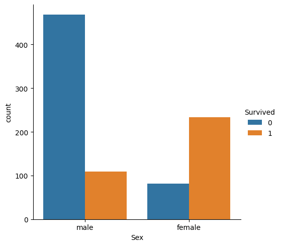

```python
import seaborn as sns
import matplotlib.pyplot as plt

# Countplot
sns.catplot(x ="Sex", hue ="Survived",
kind ="count", data = data)
```

**5.) Create **3** graphs that separates all passengers by PClass (level of impportance; 1 being most important, 3 being least). Each graph should have the information of which port they embarked on and if they survived.**

To complete this query, we will create a 3 catplot graphs with the x-axis as where they embarked (S = Southhampton, C = Cherbourg, Q = Queenstown) and the y-axis as the number of people that survived or died.

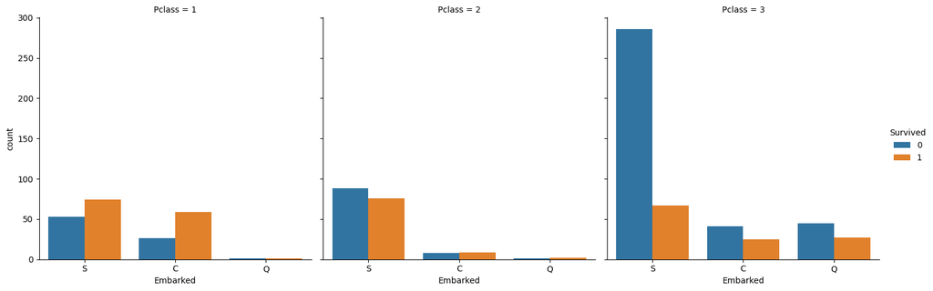

```python
sns.catplot(x ='Embarked', hue ='Survived',
kind ='count', col ='Pclass', data = data)
```

Based on the results of the code, we can see that the least amount of people died in first class, second class is int he middle, and the 3rd/ last class has the most amount of deaths on the Titanic ship. There is most likely some correlation to the number of deaths being people from the last class because they were most likely the working class on the ship; the people that cleaned, cooked, played music on the ship, served the first class passengers, etc. The people that worked on the ship were often looked at as unimportant and not as valuable as the first class people since they did not have as much money as them. We can also see that majority of the passengers out of all 3 ports embarked on the Southhampton port.

**6.) Display a histogram graph that shows all the passengers on the Titanic ship age and how many passengers had the same age.**

A histogram function can be used to take the data from the table and display a graph that shows all the ages of every passenger on the Titanic and how many passengers had the same age

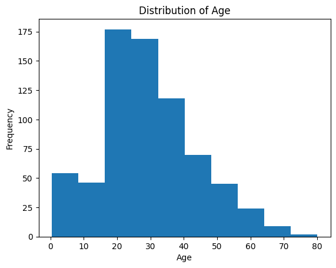

```python
plt.hist(data['Age'], bins=10)
plt.xlabel('Age')
plt.ylabel('Frequency')
plt.title('Distribution of Age')
plt.show()
```

We can conclude that when looking at the graph that most of the passengers on the Titanic were around the ages of 20-40 years old. There were still many kids on the ship ranging from the ages of 1 to 10-years-old with more than 50 kids on the ship. There were many people with many ages on the ship that range from 1 to around 80-years-old in age. This graph shows that there is a wide variety of people that are different ages that had to suffer from the tragic sinking of this ship. This means that people as young as 1-years-old could have died from the sinking of the ship. Even those that survived have had to live with this tragedy for the rest of their lives, especially if they had family and loved ones on the ship that did not survive with them.

# Now that we have finished looking at the dataset for the sinking of the Titanic ship, we can confirm that we learned a lot about datasets, how to write code that extracts certain data from the table, and how to understand the data extracted. We learned how to clean datasets (if needed) and how to frame queries that we can use to understand what the data means. We have successfully understood the sinking of the Titanic ship and can use the different function we learned to extract data to look at other tables in the future and extract data from those.